# Binary Classification: Scikit-Learn

#### 2.21 Populating unique values of categorical variables

```python
col = cat.shape[1]
l=list(cat)
print ("Total number of categorical columns: ",col)
for i in range(col):
    d = cat.iloc[:,i].unique()
    print ("\n",l[i],"\n")
    print ("\n",d)
```

```
Total number of categorical columns:  28

 diag_1


 ['250.83' '276' '648' '8' '197' '414' '428' '398' '434' '250.7' '157'
 '518' '999' '410' '682' '402' '737' '572' 'V57' '189' '786' '427' '996'
 '277' '584' '462' '473' '411' '174' '486' '998' '511' '432' '626' '295'
 '196' '250.6' '618' '182' '845' '423' '808' '250.4' '722' '403' '250.11'
 '784' '707' '440' '151' '715' '997' '198' '564' '812' '38' '590' '556'
 '578' '250.32' '433' 'V58' '569' '185' '536' '255' '250.13' '599' '558'
 '574' '491' '560' '244' '250.03' '577' '730' '188' '824' '250.8' '332'
 '562' '291' '296' '510' '401' '263' '438' '70' '250.02' '493' '642' '625'
 '571' '738' '593' '250.42' '807' '456' '446' '575' '250.41' '820' '515'
 '780' '250.22' '995' '235' '250.82' '721' '787' '162' '724' '282' '514'
 'V55' '281' '250.33' '530' '466' '435' '250.12' 'V53' '789' '566' '822'
 '191' '557' '733' '455' '711' '482' '202' '280' '553' '225' '154' '441'
 '250.81' '349' '?' '962' '592' '507' '386' '156' '200' '728' '348' '459'
 '426' '388' '607' '337' '82' '531' '596' '288' '656' '573' '492' '220'
 '516' '210' '922' '286' '885' '958' '661' '969' '250.93' '227' '112'
 '404' '823' '532' '416' '346' '535' '453' '250' '595' '211' '303'
 '250.01' '852' '218' '782' '540' '457' '285' '431' '340' '550' '54' '351'
 '601' '723' '555' '153' '443' '380' '204' '424' '241' '358' '694' '331'
 '345' '681' '447' '290' '158' '579' '436' '335' '309' '654' '805' '799'
 '292' '183' '78' '851' '458' '586' '311' '892' '305' '293' '415' '591'
 '794' '803' '79' '655' '429' '278' '658' '598' '729' '585' '444' '604'
 '727' '214' '552' '284' '680' '708' '41' '644' '481' '821' '413' '437'
 '968' '756' '632' '359' '275' '512' '781' '420' '368' '522' '294' '825'
 '135' '304' '320' '250.31' '669' '868' '496' '250.43' '826' '567' '3'
 '203' '53' '251' '565' '161' '495' '49' '250.1' '297' '663' '576' '355'
 '850' '287' '250.2' '611' '840' '350' '726' '537' '620' '180' '366' '783'
 '11' '751' '716' '250.3' '199' '464' '580' '836' '664' '283' '813' '966'
 '289' '965' '184' '480' '608' '333' '972' '212' '117' '788' '924' '959'
 '621' '238' '785' '714' '942' '250.23' '710' '47' '933' '508' '478' '844'
 '7' '736' '233' '42' '250.5' '397' '395' '201' '421' '253' '250.92' '600'
 '494' '977' '39' '659' '312' '614' '647' '652' '646' '274' '861' '425'
 '527' '451' '485' '217' '250.53' '442' '970' '193' '160' '322' '581'
 '475' '623' '374' '582' '568' '465' '801' '237' '376' '150' '461' '913'
 '226' '617' '987' '641' '298' '790' '336' '362' '228' '513' '383' '746'
 '353' '911' '506' '873' '155' '860' '534' '802' '141' 'V45' '396' '310'
```

[output cut: 268 more lines]

```

 glimepiride-pioglitazone


 ['No' nan]

 metformin-rosiglitazone


 ['No' nan]

 metformin-pioglitazone


 ['No' nan]
```

#### 2.22 Dropping useless columns (medicines) for time being; also, they have large number of categorical levels

```python
cols = [10,11,12,13,14,15,16,17,18,19,20,21,22,23,24,25,26,27,28,29,30,31,32,34,35,36,37,38]
df.drop(df.columns[cols],axis=1,inplace=True)
```

#### 2.23 One hot encoding insulin variable

```python
df=pd.get_dummies(df, columns=["insulin"])
```

#### 2.24 Checking number of observations and variables

```python
df.shape
```

```
(74783, 28)
```

#### 2.25 Storing numerical variables in one place

```python
num = df.select_dtypes(include=['int64'])
```

#### 2.26 Populating 10 rows of the numerical variables

```python
num.head()
```

|  | admission_type_id | discharge_disposition_id | admission_source_id | time_in_hospital | num_lab_procedures | num_procedures | num_medications | number_outpatient | number_emergency | number_inpatient | change_enc | gender_enc |
| --- | --- | --- | --- | --- | --- | --- | --- | --- | --- | --- | --- | --- |
| 0 | 6 | 25 | 1 | 1 | 41 | 0 | 1 | 0 | 0 | 0 | 1 | 0 |
| 1 | 1 | 1 | 7 | 3 | 59 | 0 | 18 | 0 | 0 | 0 | 0 | 0 |
| 2 | 1 | 1 | 7 | 2 | 11 | 5 | 13 | 2 | 0 | 1 | 1 | 0 |
| 3 | 1 | 1 | 7 | 2 | 44 | 1 | 16 | 0 | 0 | 0 | 0 | 1 |
| 4 | 1 | 1 | 7 | 1 | 51 | 0 | 8 | 0 | 0 | 0 | 0 | 1 |

#### 2.27 Populating unique values of numerical variables

```python
col = num.shape[1]
l=list(num)
print ("Total number of numerical columns: ",col)
for i in range(col):
    d = num.iloc[:,i].unique()
    print ("\n",l[i],"\n")
    print ("\n",d)
```

```
Total number of numerical columns:  12

 admission_type_id


 [6 1 2 3 4 5 8 7]

 discharge_disposition_id


 [25  1  3  6  2  5 11  7 10  4 14 18  8 13 12 16 17 22 23  9 20 15 24 28
 19 27]

 admission_source_id


 [ 1  7  2  4  5  6 20  3 17  8  9 14 10 22]

 time_in_hospital


 [ 1  3  2  4  5 13 12  9  7 10  6 11  8 14]

 num_lab_procedures


 [ 41  59  11  44  51  31  70  73  68  33  47  62  60  55  49  75  45  29
  35  42  66  36  19  64  25  53  52  87  27  37  46  28  48  72  10   2
  65  67  40  54  58  57  43  32  83  34  39  69  38  56  22  96  78  61
  88  50   1  18  82   9  63  24  71  77  81  76  90  93   3 103  13  80
  85  16  15  12  30  23  17  21  79  26   5  95  97  84  14  74 105  86
  98  20   6  94   8 102 100   7  89  91  92   4 101  99 114 113 111 129
 107 108 106 104 109 120]

 num_procedures


 [0 5 1 6 2 3 4]

 num_medications
```

[output cut: 17 more lines]

```

 number_inpatient


 [ 0  1  2  3  6  5  4  7  8  9 15 10 11 14 12 13 17 16 21 18 19]

 change_enc


 [1 0 2]

 gender_enc


 [0 1 2]
```

#### 2.28 Inspecting data

```python
df.head()
```

|  | admission_type_id | discharge_disposition_id | admission_source_id | time_in_hospital | num_lab_procedures | num_procedures | num_medications | number_outpatient | number_emergency | number_inpatient | ... | race_Caucasian | race_Hispanic | race_Other | readmitted_<30 | readmitted_>30 | readmitted_NO | insulin_Down | insulin_No | insulin_Steady | insulin_Up |
| --- | --- | --- | --- | --- | --- | --- | --- | --- | --- | --- | --- | --- | --- | --- | --- | --- | --- | --- | --- | --- | --- |
| 0 | 6 | 25 | 1 | 1 | 41 | 0 | 1 | 0 | 0 | 0 | ... | 1 | 0 | 0 | 0 | 0 | 1 | 0 | 1 | 0 | 0 |
| 1 | 1 | 1 | 7 | 3 | 59 | 0 | 18 | 0 | 0 | 0 | ... | 1 | 0 | 0 | 0 | 1 | 0 | 0 | 0 | 0 | 1 |
| 2 | 1 | 1 | 7 | 2 | 11 | 5 | 13 | 2 | 0 | 1 | ... | 0 | 0 | 0 | 0 | 0 | 1 | 0 | 1 | 0 | 0 |
| 3 | 1 | 1 | 7 | 2 | 44 | 1 | 16 | 0 | 0 | 0 | ... | 1 | 0 | 0 | 0 | 0 | 1 | 0 | 0 | 0 | 1 |
| 4 | 1 | 1 | 7 | 1 | 51 | 0 | 8 | 0 | 0 | 0 | ... | 1 | 0 | 0 | 0 | 0 | 1 | 0 | 0 | 1 | 0 |

5 rows × 28 columns

- Now all the required variables are transformed to numeric.

#### 2.29 Scaling all the independent variables

```python
#Dropping dependent variable
df_scaled_temp = df.drop(['change_enc'], axis=1)
df_scaled_temp.shape
```

```
(74783, 27)
```

```python
#Scaling all independent variables
from sklearn.preprocessing import MinMaxScaler

scaler = MinMaxScaler()
df_scaled = scaler.fit_transform(df_scaled_temp)
df_scaled.shape
```

```
(74783, 27)
```

```python
#Storing scaled data into a dataframe
df_temp = pd.DataFrame(df_scaled)
col_list = list(df_scaled_temp)
```

```python
#Checking data
df_temp.head()
```

|  | 0 | 1 | 2 | 3 | 4 | 5 | 6 | 7 | 8 | 9 | ... | 17 | 18 | 19 | 20 | 21 | 22 | 23 | 24 | 25 | 26 |
| --- | --- | --- | --- | --- | --- | --- | --- | --- | --- | --- | --- | --- | --- | --- | --- | --- | --- | --- | --- | --- | --- |
| 0 | 0.714286 | 0.888889 | 0.000000 | 0.000000 | 0.312500 | 0.000000 | 0.0000 | 0.000000 | 0.0 | 0.000000 | ... | 1.0 | 0.0 | 0.0 | 0.0 | 0.0 | 1.0 | 0.0 | 1.0 | 0.0 | 0.0 |
| 1 | 0.000000 | 0.000000 | 0.285714 | 0.153846 | 0.453125 | 0.000000 | 0.2125 | 0.000000 | 0.0 | 0.000000 | ... | 1.0 | 0.0 | 0.0 | 0.0 | 1.0 | 0.0 | 0.0 | 0.0 | 0.0 | 1.0 |
| 2 | 0.000000 | 0.000000 | 0.285714 | 0.076923 | 0.078125 | 0.833333 | 0.1500 | 0.047619 | 0.0 | 0.047619 | ... | 0.0 | 0.0 | 0.0 | 0.0 | 0.0 | 1.0 | 0.0 | 1.0 | 0.0 | 0.0 |
| 3 | 0.000000 | 0.000000 | 0.285714 | 0.076923 | 0.335938 | 0.166667 | 0.1875 | 0.000000 | 0.0 | 0.000000 | ... | 1.0 | 0.0 | 0.0 | 0.0 | 0.0 | 1.0 | 0.0 | 0.0 | 0.0 | 1.0 |
| 4 | 0.000000 | 0.000000 | 0.285714 | 0.000000 | 0.390625 | 0.000000 | 0.0875 | 0.000000 | 0.0 | 0.000000 | ... | 1.0 | 0.0 | 0.0 | 0.0 | 0.0 | 1.0 | 0.0 | 0.0 | 1.0 | 0.0 |

5 rows × 27 columns

```python
#Providing corresponding column names
df_temp.columns = col_list
```

```python
#Checking data
df_temp.head()
```

|  | admission_type_id | discharge_disposition_id | admission_source_id | time_in_hospital | num_lab_procedures | num_procedures | num_medications | number_outpatient | number_emergency | number_inpatient | ... | race_Caucasian | race_Hispanic | race_Other | readmitted_<30 | readmitted_>30 | readmitted_NO | insulin_Down | insulin_No | insulin_Steady | insulin_Up |
| --- | --- | --- | --- | --- | --- | --- | --- | --- | --- | --- | --- | --- | --- | --- | --- | --- | --- | --- | --- | --- | --- |
| 0 | 0.714286 | 0.888889 | 0.000000 | 0.000000 | 0.312500 | 0.000000 | 0.0000 | 0.000000 | 0.0 | 0.000000 | ... | 1.0 | 0.0 | 0.0 | 0.0 | 0.0 | 1.0 | 0.0 | 1.0 | 0.0 | 0.0 |
| 1 | 0.000000 | 0.000000 | 0.285714 | 0.153846 | 0.453125 | 0.000000 | 0.2125 | 0.000000 | 0.0 | 0.000000 | ... | 1.0 | 0.0 | 0.0 | 0.0 | 1.0 | 0.0 | 0.0 | 0.0 | 0.0 | 1.0 |
| 2 | 0.000000 | 0.000000 | 0.285714 | 0.076923 | 0.078125 | 0.833333 | 0.1500 | 0.047619 | 0.0 | 0.047619 | ... | 0.0 | 0.0 | 0.0 | 0.0 | 0.0 | 1.0 | 0.0 | 1.0 | 0.0 | 0.0 |
| 3 | 0.000000 | 0.000000 | 0.285714 | 0.076923 | 0.335938 | 0.166667 | 0.1875 | 0.000000 | 0.0 | 0.000000 | ... | 1.0 | 0.0 | 0.0 | 0.0 | 0.0 | 1.0 | 0.0 | 0.0 | 0.0 | 1.0 |
| 4 | 0.000000 | 0.000000 | 0.285714 | 0.000000 | 0.390625 | 0.000000 | 0.0875 | 0.000000 | 0.0 | 0.000000 | ... | 1.0 | 0.0 | 0.0 | 0.0 | 0.0 | 1.0 | 0.0 | 0.0 | 1.0 | 0.0 |

5 rows × 27 columns

```python
#Adding dependent variable
df_temp = pd.concat([df_temp,df[['change_enc']]],axis=1)
```

```python
#Checking data
df_temp.head(20)
```

|  | admission_type_id | discharge_disposition_id | admission_source_id | time_in_hospital | num_lab_procedures | num_procedures | num_medications | number_outpatient | number_emergency | number_inpatient | ... | race_Hispanic | race_Other | readmitted_<30 | readmitted_>30 | readmitted_NO | insulin_Down | insulin_No | insulin_Steady | insulin_Up | change_enc |
| --- | --- | --- | --- | --- | --- | --- | --- | --- | --- | --- | --- | --- | --- | --- | --- | --- | --- | --- | --- | --- | --- |
| 0 | 0.714286 | 0.888889 | 0.000000 | 0.000000 | 0.312500 | 0.000000 | 0.0000 | 0.000000 | 0.00000 | 0.000000 | ... | 0.0 | 0.0 | 0.0 | 0.0 | 1.0 | 0.0 | 1.0 | 0.0 | 0.0 | 1 |
| 1 | 0.000000 | 0.000000 | 0.285714 | 0.153846 | 0.453125 | 0.000000 | 0.2125 | 0.000000 | 0.00000 | 0.000000 | ... | 0.0 | 0.0 | 0.0 | 1.0 | 0.0 | 0.0 | 0.0 | 0.0 | 1.0 | 0 |
| 2 | 0.000000 | 0.000000 | 0.285714 | 0.076923 | 0.078125 | 0.833333 | 0.1500 | 0.047619 | 0.00000 | 0.047619 | ... | 0.0 | 0.0 | 0.0 | 0.0 | 1.0 | 0.0 | 1.0 | 0.0 | 0.0 | 1 |
| 3 | 0.000000 | 0.000000 | 0.285714 | 0.076923 | 0.335938 | 0.166667 | 0.1875 | 0.000000 | 0.00000 | 0.000000 | ... | 0.0 | 0.0 | 0.0 | 0.0 | 1.0 | 0.0 | 0.0 | 0.0 | 1.0 | 0 |
| 4 | 0.000000 | 0.000000 | 0.285714 | 0.000000 | 0.390625 | 0.000000 | 0.0875 | 0.000000 | 0.00000 | 0.000000 | ... | 0.0 | 0.0 | 0.0 | 0.0 | 1.0 | 0.0 | 0.0 | 1.0 | 0.0 | 0 |
| 5 | 0.142857 | 0.000000 | 0.047619 | 0.153846 | 0.234375 | 1.000000 | 0.1875 | 0.000000 | 0.00000 | 0.000000 | ... | 0.0 | 0.0 | 0.0 | 1.0 | 0.0 | 0.0 | 0.0 | 1.0 | 0.0 | 1 |
| 6 | 0.285714 | 0.000000 | 0.047619 | 0.230769 | 0.539062 | 0.166667 | 0.2500 | 0.000000 | 0.00000 | 0.000000 | ... | 0.0 | 0.0 | 0.0 | 0.0 | 1.0 | 0.0 | 0.0 | 1.0 | 0.0 | 0 |
| 7 | 0.000000 | 0.000000 | 0.285714 | 0.307692 | 0.562500 | 0.000000 | 0.1375 | 0.000000 | 0.00000 | 0.000000 | ... | 0.0 | 0.0 | 0.0 | 1.0 | 0.0 | 0.0 | 1.0 | 0.0 | 0.0 | 1 |
| 8 | 0.142857 | 0.000000 | 0.142857 | 0.923077 | 0.523438 | 0.333333 | 0.3375 | 0.000000 | 0.00000 | 0.000000 | ... | 0.0 | 0.0 | 0.0 | 0.0 | 1.0 | 0.0 | 0.0 | 1.0 | 0.0 | 0 |
| 9 | 0.285714 | 0.074074 | 0.142857 | 0.846154 | 0.250000 | 0.500000 | 0.2125 | 0.000000 | 0.00000 | 0.000000 | ... | 0.0 | 0.0 | 0.0 | 0.0 | 1.0 | 0.0 | 0.0 | 1.0 | 0.0 | 0 |
| 10 | 0.000000 | 0.000000 | 0.285714 | 0.615385 | 0.359375 | 0.333333 | 0.2000 | 0.000000 | 0.00000 | 0.000000 | ... | 0.0 | 0.0 | 0.0 | 1.0 | 0.0 | 0.0 | 0.0 | 1.0 | 0.0 | 1 |
| 11 | 0.142857 | 0.000000 | 0.142857 | 0.461538 | 0.476562 | 0.000000 | 0.1250 | 0.000000 | 0.00000 | 0.000000 | ... | 0.0 | 0.0 | 1.0 | 0.0 | 0.0 | 0.0 | 0.0 | 1.0 | 0.0 | 0 |
| 12 | 0.000000 | 0.074074 | 0.285714 | 0.461538 | 0.460938 | 0.000000 | 0.1750 | 0.000000 | 0.02381 | 0.000000 | ... | 0.0 | 0.0 | 1.0 | 0.0 | 0.0 | 1.0 | 0.0 | 0.0 | 0.0 | 0 |
| 13 | 0.000000 | 0.185185 | 0.285714 | 0.692308 | 0.421875 | 0.166667 | 0.3750 | 0.000000 | 0.00000 | 0.000000 | ... | 0.0 | 0.0 | 0.0 | 0.0 | 1.0 | 0.0 | 0.0 | 1.0 | 0.0 | 1 |
| 14 | 0.285714 | 0.000000 | 0.047619 | 0.000000 | 0.375000 | 0.833333 | 0.0125 | 0.000000 | 0.00000 | 0.000000 | ... | 0.0 | 0.0 | 0.0 | 1.0 | 0.0 | 0.0 | 0.0 | 1.0 | 0.0 | 1 |
| 15 | 0.000000 | 0.074074 | 0.285714 | 0.846154 | 0.578125 | 0.833333 | 0.1500 | 0.000000 | 0.00000 | 0.000000 | ... | 0.0 | 0.0 | 0.0 | 0.0 | 1.0 | 0.0 | 0.0 | 0.0 | 1.0 | 0 |
| 16 | 0.000000 | 0.000000 | 0.285714 | 0.230769 | 0.343750 | 0.666667 | 0.2000 | 0.000000 | 0.00000 | 0.000000 | ... | 0.0 | 0.0 | 1.0 | 0.0 | 0.0 | 0.0 | 0.0 | 1.0 | 0.0 | 0 |
| 17 | 0.000000 | 0.000000 | 0.285714 | 0.153846 | 0.218750 | 0.000000 | 0.1250 | 0.000000 | 0.00000 | 0.000000 | ... | 0.0 | 0.0 | 0.0 | 0.0 | 1.0 | 0.0 | 1.0 | 0.0 | 0.0 | 1 |
| 18 | 0.000000 | 0.000000 | 0.285714 | 0.307692 | 0.265625 | 0.833333 | 0.2750 | 0.000000 | 0.00000 | 0.000000 | ... | 0.0 | 0.0 | 0.0 | 1.0 | 0.0 | 0.0 | 0.0 | 1.0 | 0.0 | 1 |
| 19 | 0.285714 | 0.185185 | 0.047619 | 0.384615 | 0.320312 | 0.333333 | 0.2750 | 0.000000 | 0.00000 | 0.000000 | ... | 0.0 | 0.0 | 0.0 | 0.0 | 1.0 | 0.0 | 0.0 | 1.0 | 0.0 | 0 |

20 rows × 28 columns

```python
#Clearing memory
del df
df = pd.DataFrame(df_temp)
del df_temp
df.head()
```

|  | admission_type_id | discharge_disposition_id | admission_source_id | time_in_hospital | num_lab_procedures | num_procedures | num_medications | number_outpatient | number_emergency | number_inpatient | ... | race_Hispanic | race_Other | readmitted_<30 | readmitted_>30 | readmitted_NO | insulin_Down | insulin_No | insulin_Steady | insulin_Up | change_enc |
| --- | --- | --- | --- | --- | --- | --- | --- | --- | --- | --- | --- | --- | --- | --- | --- | --- | --- | --- | --- | --- | --- |
| 0 | 0.714286 | 0.888889 | 0.000000 | 0.000000 | 0.312500 | 0.000000 | 0.0000 | 0.000000 | 0.0 | 0.000000 | ... | 0.0 | 0.0 | 0.0 | 0.0 | 1.0 | 0.0 | 1.0 | 0.0 | 0.0 | 1 |
| 1 | 0.000000 | 0.000000 | 0.285714 | 0.153846 | 0.453125 | 0.000000 | 0.2125 | 0.000000 | 0.0 | 0.000000 | ... | 0.0 | 0.0 | 0.0 | 1.0 | 0.0 | 0.0 | 0.0 | 0.0 | 1.0 | 0 |
| 2 | 0.000000 | 0.000000 | 0.285714 | 0.076923 | 0.078125 | 0.833333 | 0.1500 | 0.047619 | 0.0 | 0.047619 | ... | 0.0 | 0.0 | 0.0 | 0.0 | 1.0 | 0.0 | 1.0 | 0.0 | 0.0 | 1 |
| 3 | 0.000000 | 0.000000 | 0.285714 | 0.076923 | 0.335938 | 0.166667 | 0.1875 | 0.000000 | 0.0 | 0.000000 | ... | 0.0 | 0.0 | 0.0 | 0.0 | 1.0 | 0.0 | 0.0 | 0.0 | 1.0 | 0 |
| 4 | 0.000000 | 0.000000 | 0.285714 | 0.000000 | 0.390625 | 0.000000 | 0.0875 | 0.000000 | 0.0 | 0.000000 | ... | 0.0 | 0.0 | 0.0 | 0.0 | 1.0 | 0.0 | 0.0 | 1.0 | 0.0 | 0 |

5 rows × 28 columns

```python
#Reversing polarity of target variable
df['change_enc']=np.where(df['change_enc'] == 0, 1, 0)
```

#### 2.30 Plotting heat map

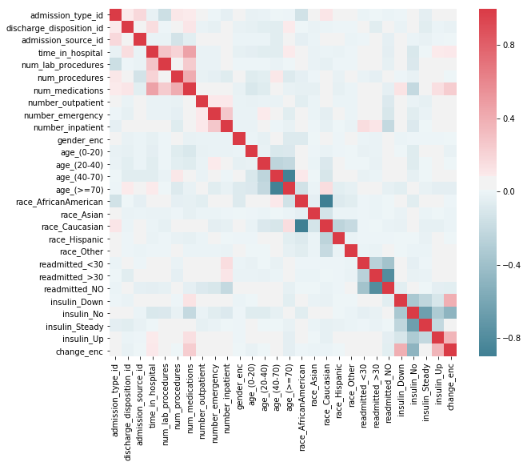

```python
import seaborn as sns
f, ax = plt.subplots(figsize=(10, 8))
corr = df.corr()
sns.heatmap(corr, mask=np.zeros_like(corr, dtype=np.bool), cmap=sns.diverging_palette(220, 10, as_cmap=True),
            square=True, ax=ax)
```

#### 2.31 Oversampling dependent variable (Oversampling) and creating Training and Test datasets

- The responses of No and Ch (Yes) is not equal in our dependent variable. Using SMOTE, we will oversample data.
- The oversampling here is done on Training set which is an efficient way rather than oversampling the whole dataset.

```python
#Splitting the dataset into training set and test set in 70:30
from sklearn import metrics
import warnings
warnings.simplefilter("ignore")

X = df.loc[:, df.columns != 'change_enc']
y = df.loc[:, df.columns == 'change_enc']
X_train, X_test, y_train, y_test = train_test_split(X, y, test_size=0.3, random_state=10)
columns = X_train.columns

from imblearn.over_sampling import SMOTE
sm = SMOTE(random_state=12, ratio = 1.0)
X_train, y_train = sm.fit_sample(X_train, y_train)
col_list=df.columns.values.tolist()
```

#### 2.32 Inspecting the number of observations and variables in Training and Test set

```python
print("Number of observations and variables in training set: ",X_train.shape)
print("Number of observations and variables in test set: ",X_test.shape)
```

```
Number of observations and variables in training set:  (58470, 27)
Number of observations and variables in test set:  (22435, 27)
```

#### 2.33 Inspecting number of observations in oversample data

```python
print("Number of 1 in oversampled data",len(y_train ==0))
print("Number of 1 in oversampled data",len(y_train ==1))
```

```
Number of 1 in oversampled data 58470
Number of 1 in oversampled data 58470
```

## 3. Model Creation

### 3.1 Logistic Regression Classification

#### 3.1.1 Fitting Logistic Regression Model

```python
from sklearn.linear_model import LogisticRegression

logreg = LogisticRegression()
logreg.fit(X_train, y_train)
```

```
LogisticRegression(C=1.0, class_weight=None, dual=False, fit_intercept=True,
          intercept_scaling=1, max_iter=100, multi_class='ovr', n_jobs=1,
          penalty='l2', random_state=None, solver='liblinear', tol=0.0001,
          verbose=0, warm_start=False)
```

- The model is created on all the 27 variables.

#### 3.1.2 Checking the accuracy of the model

```python
y_pred = logreg.predict(X_test)
print('Accuracy of logistic regression classifier on test set: {:.2f}'.format(logreg.score(X_test, y_test)))
```

```
Accuracy of logistic regression classifier on test set: 0.78
```

- The accuracy of the model is **78%**, which is good but not the best.

#### 3.1.3 Confusion matrix

```python
from sklearn.metrics import confusion_matrix
confusion_matrix = confusion_matrix(y_test, y_pred)
print(confusion_matrix)
```

```
[[10505  2030]
 [ 2974  6926]]
```

#### 3.1.4 Model metrics

```python
from sklearn.metrics import classification_report
print(classification_report(y_test, y_pred))
```

```
             precision    recall  f1-score   support

          0       0.78      0.84      0.81     12535
          1       0.77      0.70      0.73      9900

avg / total       0.78      0.78      0.78     22435
```

#### 3.1.5 ROC Curve

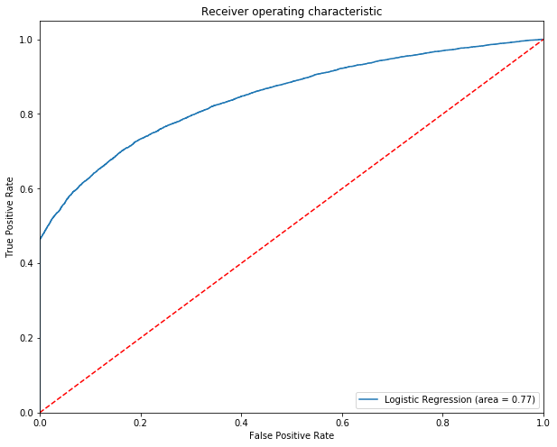

```python
from sklearn.metrics import roc_auc_score
from sklearn.metrics import roc_curve

logit_roc_auc = roc_auc_score(y_test, logreg.predict(X_test))
fpr, tpr, thresholds = roc_curve(y_test, logreg.predict_proba(X_test)[:,1])
plt.rcParams['figure.figsize'] = [10, 8]
plt.figure()
plt.plot(fpr, tpr, label='Logistic Regression (area = %0.2f)' % logit_roc_auc)
plt.plot([0, 1], [0, 1],'r--')
plt.xlim([0.0, 1.0])
plt.ylim([0.0, 1.05])
plt.xlabel('False Positive Rate')
plt.ylabel('True Positive Rate')
plt.title('Receiver operating characteristic')
plt.legend(loc="lower right")
plt.savefig('Log_ROC')
plt.show()
```

#### 3.1.6 k-fold-cross-validation

```python
from sklearn.model_selection import cross_val_score
accuracies = cross_val_score(estimator=logreg, X=X_train,y=y_train, cv=10)
print("Mean accuracy: %0.2f"%accuracies.mean())
print("Standard deviation: %0.2f"%accuracies.std())
```

```
Mean accuracy: 0.78
Standard deviation: 0.00
```

- For 10 folds, the mean accuracy is **78%** and mean standard deviation is **0%** which is quite good. But, it seems the model is overfitting the data.

#### 3.1.7 Feature selection

- Using recursive elimination technique to extract important features.

```python
#The index where values are True are the columns we have to consider. We are asking for 20 variables.
y=['change_enc']
X=[i for i in col_list if i not in y]

from sklearn.feature_selection import RFE
from sklearn.linear_model import LogisticRegression

logreg = LogisticRegression()

rfe = RFE(logreg, 20)
rfe = rfe.fit(X_train, y_train)
print(rfe.support_)
print(rfe.ranking_)
```

```
[False  True False False  True  True  True  True  True  True  True  True
  True  True  True False False False  True False  True  True  True  True
  True  True  True]
[7 1 5 6 1 1 1 1 1 1 1 1 1 1 1 8 2 4 1 3 1 1 1 1 1 1 1]
```

- The values are rank of corresponding variables according to importance.